# Trustworthiness Assessment of Harkin et al. 2016

Ian Hussey

12 February, 2026

# Rationale for Trustworthiness Assessment

cited 741 times since publication - it is a load-bearing publication for the field.

[Harkin et al.’s 2016](https://doi.org/10.1037/bul0000025) meta-analysis reports at least 18 effect sizes that are larger than Cohen’s d of 4, which are in the top 1% of Cohen’s d effect sizes reported in contemporary psychology meta-analyses by [Stanley et al. (2018)](https://doi.org/10.1037/bul0000169). Harkin et al.’s (2016) are included in Stanley et al., which is how I became aware of them.

The subset of “no monitoring” progress monitoring effects in the moderator meta analysis reported in table 3 report massive average effect sizes, eg MA everage Cohen’s d = 3.34. A single study having a cohen’s d of 3.34 would already be a suspicious outlier, the meta effect being estimated to be this size should raise serious concerns.

Given that this study extracts its data from psychological studies on various health interventions and related studies, there is no reason to believe that it’s included effect sizes should be so exceptionally large. I therefore performed spot checks to try to reproduce some of the largest effects included in the meta-analysis.

## Summary of domains included in the meta

1. Physical Health and Disease Management

This is the most represented domain in the meta-analysis. The authors focused heavily on “objective” biological markers that could be influenced by progress monitoring.

Diabetes: Studies involving Self-Monitoring of Blood Glucose (SMBG) to manage HbA1c levels (e.g., Abraira et al., 1995; Acharya et al., 2011).

Cardiovascular Health: Monitoring blood pressure or cholesterol levels (Hyman et al., 1998; Logan et al., 2012).

Respiratory Health: Asthma management and lung function monitoring (Berg et al., 1997; Janson et al., 2003).

2. Lifestyle and Prevention

These studies focus on behaviors that are generally considered “health-promoting” but are notoriously difficult to maintain without self-regulation.

Weight Loss: This is a major subset of the data, involving the monitoring of weight via scales or food intake via diaries (e.g., Anderson et al., 2011; Boutelle et al., 1999).

Physical Activity: Studies using pedometers or step logs to increase movement (e.g., Andrews et al., 2011; De Cocker et al., 2008).

Smoking Cessation and Alcohol Reduction: Monitoring the number of cigarettes smoked or units of alcohol consumed (An et al., 2006; Gajecki et al., 2014).

3. Psychology and Behavioral Adherence

The “attainment” in these domains is often more about compliance with a regimen or a change in mental state.

Mental Health: Monitoring symptoms of depression or anxiety (Clarke et al., 2009).

Medication Adherence: Tracking whether patients take their prescribed prophylaxis or pills (Aronson, 2006; Suffoletto et al., 2012).

Sun Protection: A specific sub-domain involving monitoring UV exposure (Carli et al., 2008).

In summary, there is nothing obvious about these domains that would suggest that exceptionally large effect sizes would be observed on average. This raises the risk that what has occured are effect size extraction errors.

# Spot checks of original studies included in Harkin et al. 2016

## Numbers from Tan et al. (2011)

Harkin et al. includes Tan et al. (2011) as d = 14.46.

```r
library(tidyverse)
library(roundwork)

calculate_d_from_ci <- function(m1, l1, u1, m2, l2, u2, n1, n2) {
  t_crit1 <- qt(0.975, df = n1 - 1)
  t_crit2 <- qt(0.975, df = n2 - 1)

  # CI width to SD
  sd1 <- ((u1 - l1) / (2 * t_crit1)) * sqrt(n1)
  sd2 <- ((u2 - l2) / (2 * t_crit2)) * sqrt(n2)

  # pooled SD
  sd_pooled <- sqrt(((n1 - 1) * sd1^2 + (n2 - 1) * sd2^2) / (n1 + n2 - 2))

  # Cohen's d
  return((m1 - m2) / sd_pooled)
}

d_result <- calculate_d_from_ci(
  m1 = 2.88, l1 = 2.53, u1 = 3.23, # Intervention
  m2 = 0.62, l2 = 0.35, u2 = 0.89, # Control
  n1 = 82,   n2 = 82               # N per group
)
```

Recalculated d = 1.59

The result included Harkin et al. seems to be a result of treating the SD as if it is an SE, despite it being reported as an SD:

```r
calculate_mistaken_d <- function(m1, l1, u1, m2, l2, u2) {
  # 1. Mistakenly derive SE from CI width using the common "divide by 4" heuristic
  # (Assuming width = 4 * SE, although 1.96*2 would be more common)
  se1 <- (u1 - l1) / 4
  se2 <- (u2 - l2) / 4

  # 2. Mistakenly pool these SEs as if they were SDs
  se_pooled <- sqrt((se1^2 + se2^2) / 2)

  # 3. Calculate d using the SE in the denominator
  mistaken_d <- (m1 - m2) / se_pooled

  return(mistaken_d)
}

mistaken_result <- calculate_mistaken_d(
  m1 = 2.88, l1 = 2.53, u1 = 3.23, # Intervention
  m2 = 0.62, l2 = 0.35, u2 = 0.89  # Control
)
```

Recalculated d mistaking SD for SE = 14.46.

## Numbers from An et al. 2006

Harkin et al. includes An et al. (2006) as d = 10.72.

```r
library(effectsize)

# 1. Calculate the Odds Ratio manually
# (41/216) / (2/45) = 4.27
or_val <- (41/216) / (2/45)

# 2. Convert OR to Cohen's d
# Using the Cox method (default)
d_val <- oddsratio_to_d(or_val, log = FALSE)
```

Recalculated d = 0.8

## Numbers from Kroenke et al. 2010

Harkin et al. includes Kroenke et al. (2010) as d = 4.50. Its unclear if the depression variable was used at the 6 or 12 month time point, so I recalculate both.

```r
library(metafor)

# depression 6 months
escalc(measure = "SMD",
       m1i = 1.31,
       sd1i = 0.73,
       n1i = 113,
       m2i = 1.01,
       sd2i = 0.59,
       n2i = 110)
```

```
##
##       yi     vi
## 1 0.4498 0.0184
```

```r
# depression 12 months
escalc(measure = "SMD",
       m1i = 1.32,
       sd1i = 0.83,
       n1i = 105,
       m2i = 1.06,
       sd2i = 0.65,
       n2i = 98)
```

```
##
##       yi     vi
## 1 0.3460 0.0200
```

Neither match, Cohen’s d from .35 to .45.

Given these spot checks all failing to reproduce those included in the meta-analysis, and the implausibility of many of these very large effect sizes above 3 and 4, could authors comment on the accuracy of the extracted effect sizes and on the results of the meta-analysis?

```r
# also for the pain outcomes

# pain 6 months
escalc(measure = "SMD",
       m1i = 4.38,
       sd1i = 2.21,
       n1i = 103,
       m2i = 3.55,
       sd2i = 2.36,
       n2i = 103)
```

```
##
##       yi     vi
## 1 0.3617 0.0197
```

```r
# pain 12 months
escalc(measure = "SMD",
       m1i = 4.33,
       sd1i = 2.21,
       n1i = 89,
       m2i = 3.62,
       sd2i = 2.42,
       n2i = 91)
```

```
##
##       yi     vi
## 1 0.3049 0.0225
```

# Meta analysis

Effect sizes estimates extracted from the publication’s table using the ExtractTable API.

```r
library(tidyverse)
library(scales)

dat <- bind_rows(
  read_csv("../data/2 extracted/harkin1.csv"),
  read_csv("../data/2 extracted/harkin2.csv"),
  read_csv("../data/2 extracted/harkin3.csv")
) |>
  janitor::clean_names() |>
  rename(cohens_d_pm = pm, cohens_d_ga = ga)



# Robust cleaning function for meta-analytic OCR data
clean_cohens_d <- function(x) {
  if (is.na(x) || x == "") return(NA_real_)

  # 1. Preliminary cleanup (Excel errors)
  x_clean <- str_replace_all(x, "#NAME\\?", "") %>% str_trim()

  # 2. Extract the FIRST valid number
  # This correctly handles ".27**d1" -> ".27"
  # and ".88***" -> ".88" by stopping at the first non-numeric character.
  val_str <- str_extract(x_clean, "-?\\d*\\.?\\d+")

  if (is.na(val_str)) return(NA_real_)

  val <- as.numeric(val_str)

  # 3. Meta-Science Repair Step (The "Jurgens" Fix)
  # If we have a high whole number (e.g., 77) without a decimal point,
  # it's likely a missing decimal/misread star.
  if (!is.na(val) && abs(val) >= 10 && !str_detect(val_str, "\\.")) {
    val <- val / 100
  }

  return(val)
}

# Define the vectorized version for easy use in mutate
clean_cohens_d_vec <- Vectorize(clean_cohens_d)

# Apply
dat_cleaned <- dat %>%
  mutate(cohens_d_pm_clean = clean_cohens_d_vec(cohens_d_pm),
         cohens_d_ga_clean = clean_cohens_d_vec(cohens_d_ga))

# write to disk
write_csv(dat_cleaned, "../data/3 cleaned/dat_cleaned.csv")
```

## original

as described in article

```r
library(metafor)

# 1. Prepare the data and calculate variance
es_cleaned <- dat_cleaned %>%
  rename(yi = cohens_d_pm_clean) %>%
  filter(!is.na(yi)) %>% # Paper included 138 studies with valid data
  mutate(
    vi = (1/ne) + (1/nc) + (yi^2 / (2 * (ne + nc)))
  )

# 2. Winsorization (as described on page 11)
# "Outlying effect sizes (defined as +/- 3 SD from the mean)
# were winsorized and replaced with the next most extreme value."
mu_yi <- mean(es_cleaned$yi, na.rm = TRUE)
sd_yi <- sd(es_cleaned$yi, na.rm = TRUE)
lower_limit <- mu_yi - (3 * sd_yi)
upper_limit <- mu_yi + (3 * sd_yi)

# Applying Winsorization logic
es_cleaned <- es_cleaned %>%
  #arrange(yi) %>%
  mutate(yi_winsorized = case_when(
    yi > upper_limit ~ max(yi[yi <= upper_limit], na.rm = TRUE),
    yi < lower_limit ~ min(yi[yi >= lower_limit], na.rm = TRUE),
    TRUE ~ yi
  ))

# 3. Run the Meta-Analysis
# We specify method = "DL" to match Stata's 'metan' random-effects default
res <- rma(data = es_cleaned,
           yi = yi_winsorized,
           vi = vi,
           method = "DL",
           slab = study)

# 4. Results and Plotting
print(res)
```

```
##
## Random-Effects Model (k = 138; tau^2 estimator: DL)
##
## tau^2 (estimated amount of total heterogeneity): 2.2108 (SE = 0.4140)
## tau (square root of estimated tau^2 value):      1.4869
## I^2 (total heterogeneity / total variability):   97.98%
## H^2 (total variability / sampling variability):  49.51
##
## Test for Heterogeneity:
## Q(df = 137) = 6783.2013, p-val < .0001
##
## Model Results:
##
## estimate      se     zval    pval   ci.lb   ci.ub
##   1.9701  0.1301  15.1421  <.0001  1.7151  2.2251  ***
##
## ---
## Signif. codes:  0 '***' 0.001 '**' 0.01 '*' 0.05 '.' 0.1 ' ' 1
```

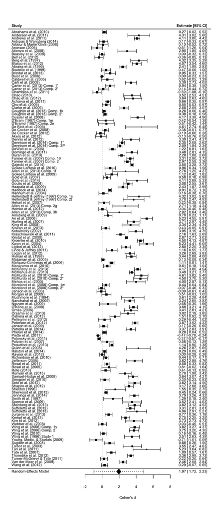

```r
forest(res, xlab = "Cohen's d", addpred = TRUE)
```

Published article: meta d = 1.98, 95% CI [1.72, 2.24]

## modern

ie not winsorisng outliers, using ML estimation rather than DL estimator.

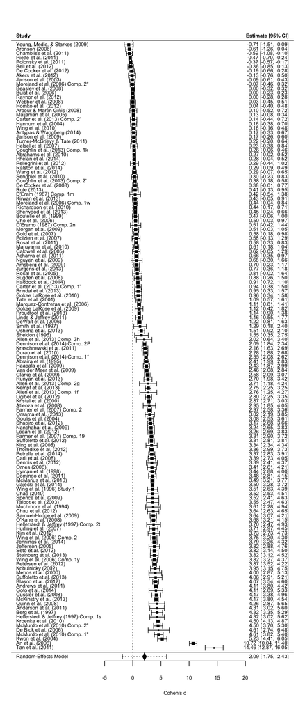

```r
es_cleaned <- dat_cleaned %>%
  rename(yi = cohens_d_pm_clean) |>
  arrange(yi) |>
  mutate(
    # 1. Calculate the Sampling Variance (vi)
    # Note: we use the cleaned version of d we created earlier
    vi = (1/ne) + (1/nc) + (yi^2 / (2 * (ne + nc)))
  )

res <- rma(data = es_cleaned,
           yi = yi,
           vi = vi,
           slab = study)

forest(res, xlab = "Cohen's d", addpred = TRUE)
```

# Distribution of ES

## Native

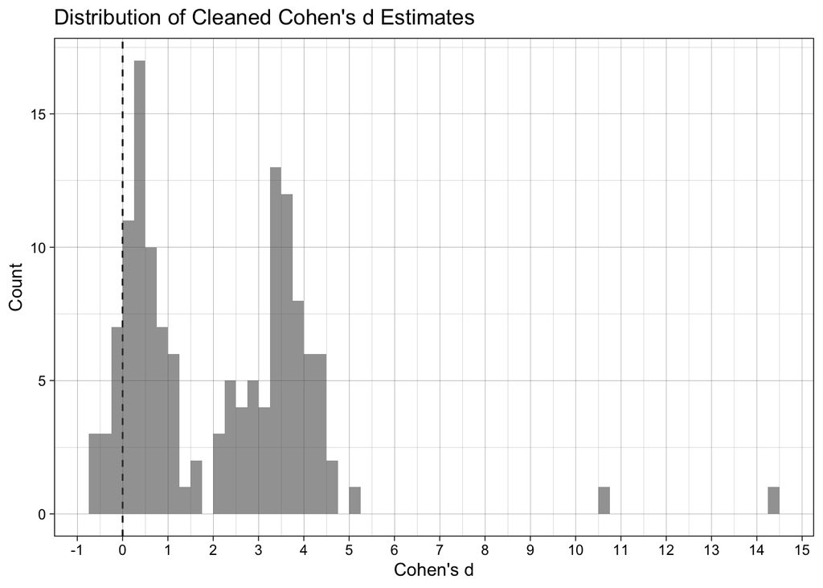

```r
ggplot(dat_cleaned, aes(x = cohens_d_pm_clean)) +
  geom_vline(xintercept = 0, linetype = "dashed") +
  geom_histogram(alpha = 0.6, position = "identity", binwidth = .25, boundary = 0) +
  scale_x_continuous(breaks = breaks_pretty(n = 20)) +
  theme_linedraw() +
  labs(title = "Distribution of Cleaned Cohen's d Estimates",
       x = "Cohen's d",
       y = "Count")
```

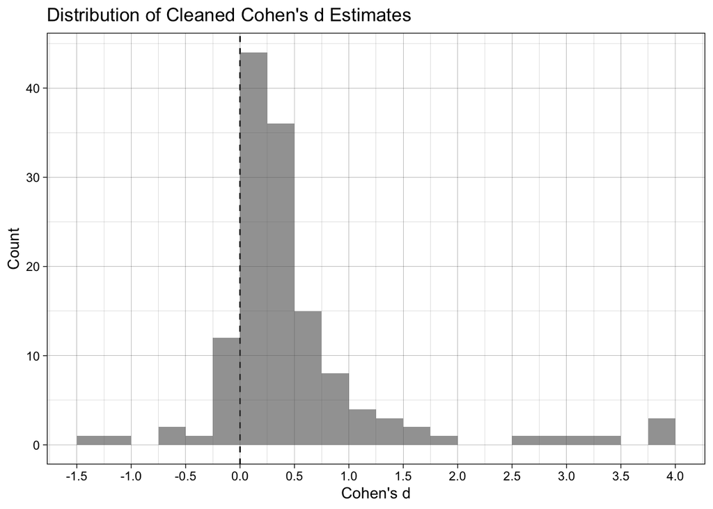

```r
ggplot(dat_cleaned, aes(x = cohens_d_ga_clean)) +
  geom_vline(xintercept = 0, linetype = "dashed") +
  geom_histogram(alpha = 0.6, position = "identity", binwidth = .25, boundary = 0) +
  scale_x_continuous(breaks = breaks_pretty(n = 20)) +
  theme_linedraw() +
  labs(title = "Distribution of Cleaned Cohen's d Estimates",
       x = "Cohen's d",
       y = "Count")
```

- Highly implausible bimodal distribution and magntidues of effect sizes for studies in this domain.

## Adjust for cases where SE was likely confused for SD (or t was reported as d)

Converting all cases where Cohen’s d > 2 as likely cases of SE/SD confusion.

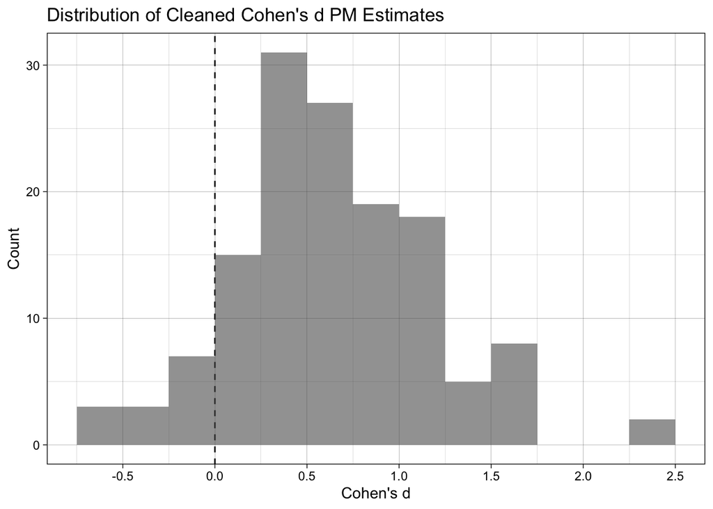

```r
dat_adjusted <- dat_cleaned %>%
  mutate(cohens_d_pm_adj = if_else(cohens_d_pm_clean > 2, cohens_d_pm_clean * sqrt(1/ne + 1/nc), cohens_d_pm_clean),
         cohens_d_ga_adj = if_else(cohens_d_ga_clean > 2, cohens_d_ga_clean * sqrt(1/ne + 1/nc), cohens_d_ga_clean))

ggplot(dat_adjusted, aes(x = cohens_d_pm_adj)) +
  geom_vline(xintercept = 0, linetype = "dashed") +
  geom_histogram(alpha = 0.6, position = "identity", binwidth = .25, boundary = 0) +
  scale_x_continuous(breaks = breaks_pretty(n = 12)) +
  theme_linedraw() +
  labs(title = "Distribution of Cleaned Cohen's d PM Estimates",
       x = "Cohen's d",
       y = "Count")
```

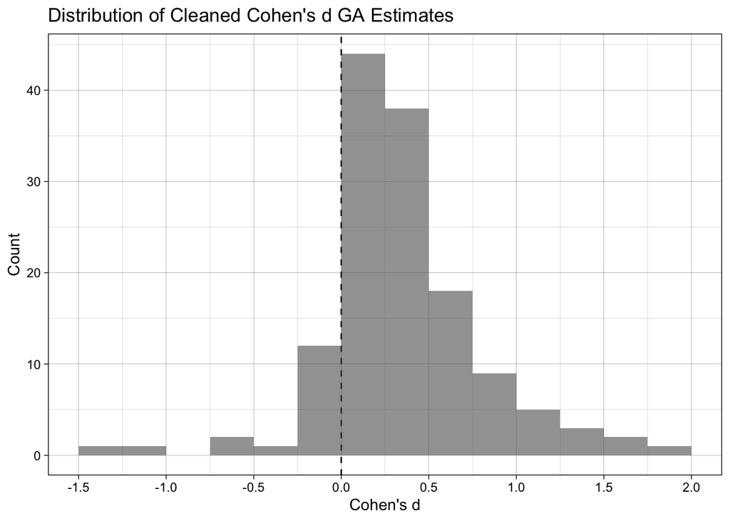

```r
ggplot(dat_adjusted, aes(x = cohens_d_ga_adj)) +
  geom_vline(xintercept = 0, linetype = "dashed") +
  geom_histogram(alpha = 0.6, position = "identity", binwidth = .25, boundary = 0) +
  scale_x_continuous(breaks = breaks_pretty(n = 12)) +
  theme_linedraw() +
  labs(title = "Distribution of Cleaned Cohen's d GA Estimates",
       x = "Cohen's d",
       y = "Count")
```

- much saner distribution.

# Alternative meta using SE/SD corrected data

Note this is not offered as the “correct” meta, which would require reextraction and validation of all effect sizes. Rather its offered as a “if the authors made this SE/SD mistake systematically for many cases, what would the corrected results look like?”. I apply the SE/SD correction for all effects where Cohen’s d > 2.

## Original meta method

as described in article

```r
library(metafor)

# 1. Prepare the data and calculate variance
es_cleaned <- dat_adjusted %>%
  rename(yi = cohens_d_pm_adj) %>%
  filter(!is.na(yi)) %>% # Paper included 138 studies with valid data
  mutate(
    vi = (1/ne) + (1/nc) + (yi^2 / (2 * (ne + nc)))
  )

# 2. Winsorization (as described on page 11)
# "Outlying effect sizes (defined as +/- 3 SD from the mean)
# were winsorized and replaced with the next most extreme value."
mu_yi <- mean(es_cleaned$yi, na.rm = TRUE)
sd_yi <- sd(es_cleaned$yi, na.rm = TRUE)
lower_limit <- mu_yi - (3 * sd_yi)
upper_limit <- mu_yi + (3 * sd_yi)

# Applying Winsorization logic
es_cleaned <- es_cleaned %>%
  #arrange(yi) %>%
  mutate(yi_winsorized = case_when(
    yi > upper_limit ~ max(yi[yi <= upper_limit], na.rm = TRUE),
    yi < lower_limit ~ min(yi[yi >= lower_limit], na.rm = TRUE),
    TRUE ~ yi
  ))

# 3. Run the Meta-Analysis
# We specify method = "DL" to match Stata's 'metan' random-effects default
res <- rma(data = es_cleaned,
           yi = yi_winsorized,
           vi = vi,
           method = "DL",
           slab = study)

# 4. Results and Plotting
print(res)
```

```
##
## Random-Effects Model (k = 138; tau^2 estimator: DL)
##
## tau^2 (estimated amount of total heterogeneity): 0.1194 (SE = 0.0249)
## tau (square root of estimated tau^2 value):      0.3456
## I^2 (total heterogeneity / total variability):   79.47%
## H^2 (total variability / sampling variability):  4.87
##
## Test for Heterogeneity:
## Q(df = 137) = 667.3606, p-val < .0001
##
## Model Results:
##
## estimate      se     zval    pval   ci.lb   ci.ub
##   0.5649  0.0360  15.7089  <.0001  0.4944  0.6353  ***
##
## ---
## Signif. codes:  0 '***' 0.001 '**' 0.01 '*' 0.05 '.' 0.1 ' ' 1
```

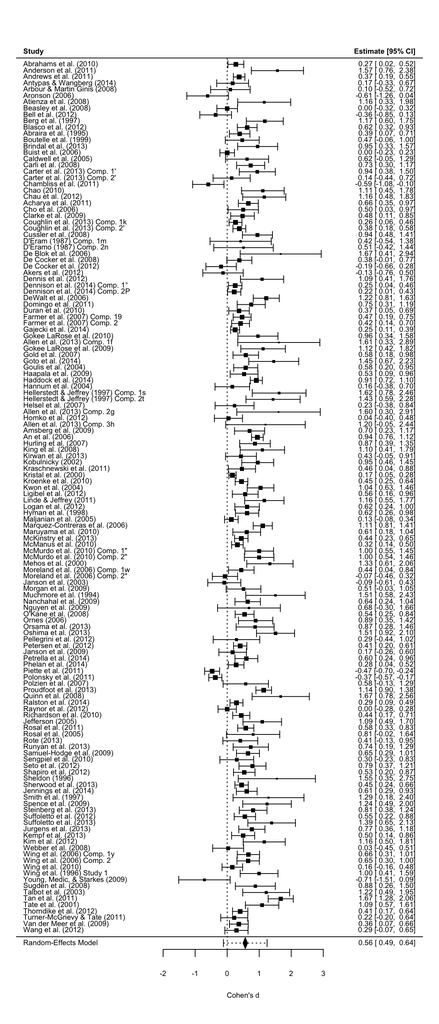

```r
forest(res, xlab = "Cohen's d", addpred = TRUE)
```

Published article: meta d = 1.98, 95% CI [1.72, 2.24]

## Modern meta method

```r
es_cleaned <- dat_adjusted %>%
  rename(yi = cohens_d_pm_adj) |>
  arrange(yi) |>
  mutate(
    # 1. Calculate the Sampling Variance (vi)
    # Note: we use the cleaned version of d we created earlier
    vi = (1/ne) + (1/nc) + (yi^2 / (2 * (ne + nc)))
  )

res <- rma(data = es_cleaned,
           yi = yi,
           vi = vi,
           slab = study)

res
```

```
##
## Random-Effects Model (k = 138; tau^2 estimator: REML)
##
## tau^2 (estimated amount of total heterogeneity): 0.1595 (SE = 0.0260)
## tau (square root of estimated tau^2 value):      0.3993
## I^2 (total heterogeneity / total variability):   83.79%
## H^2 (total variability / sampling variability):  6.17
##
## Test for Heterogeneity:
## Q(df = 137) = 716.7950, p-val < .0001
##
## Model Results:
##
## estimate      se     zval    pval   ci.lb   ci.ub
##   0.5809  0.0400  14.5112  <.0001  0.5025  0.6594  ***
##
## ---
## Signif. codes:  0 '***' 0.001 '**' 0.01 '*' 0.05 '.' 0.1 ' ' 1
```

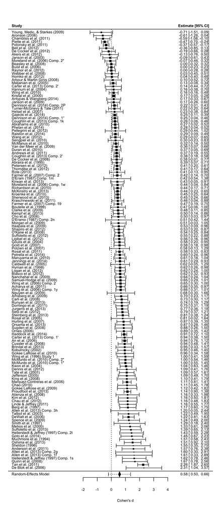

```r
forest(res, xlab = "Cohen's d", addpred = TRUE)
```

## Modern for GA outcome

```r
es_cleaned_ga <- dat_adjusted %>%
  rename(yi = cohens_d_ga_adj) |>
  arrange(yi) |>
  mutate(
    # 1. Calculate the Sampling Variance (vi)
    # Note: we use the cleaned version of d we created earlier
    vi = (1/ne) + (1/nc) + (yi^2 / (2 * (ne + nc)))
  )

res_ga <- rma(data = es_cleaned_ga,
           yi = yi,
           vi = vi,
           slab = study)

res_ga
```

```
##
## Random-Effects Model (k = 137; tau^2 estimator: REML)
##
## tau^2 (estimated amount of total heterogeneity): 0.0764 (SE = 0.0149)
## tau (square root of estimated tau^2 value):      0.2764
## I^2 (total heterogeneity / total variability):   70.94%
## H^2 (total variability / sampling variability):  3.44
##
## Test for Heterogeneity:
## Q(df = 136) = 396.7139, p-val < .0001
##
## Model Results:
##
## estimate      se     zval    pval   ci.lb   ci.ub
##   0.3336  0.0308  10.8302  <.0001  0.2732  0.3939  ***
##
## ---
## Signif. codes:  0 '***' 0.001 '**' 0.01 '*' 0.05 '.' 0.1 ' ' 1
```

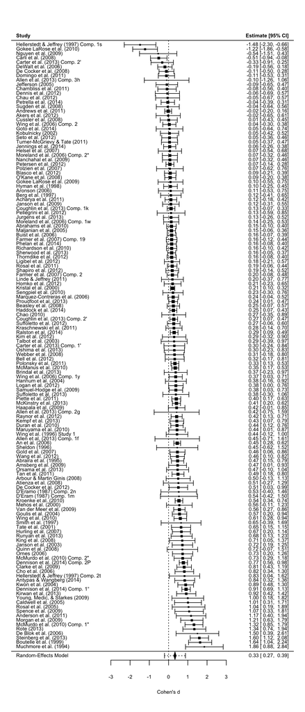

```r
forest(res_ga, xlab = "Cohen's d", addpred = TRUE)
```

Note that the published studies draws some of its conclusions from the difference in effect size between the progress monitoring (PM) vs the goal achievement (GA) effect sizes, i.e., reported overall meta results: PM Cohen’s d = 1.98, 95% CI [1.72, 2.24], GA Cohen’s d = 0.40, 95% CI [0.32, 0.48] - difference in cohen’s d = 1.58, percentage difference = 495%.

However, providing a rough correction for too-large effect sizes by recoding ES above 2 to assume they used SE instead of SD and estimating the effect sizes resulted in PM Cohen’s d = 0.58, 95% CI [0.50, 0.66], GA Cohen’s d = 0.33, 95% CI [0.27, 0.39], which differ by much less - difference in Cohen’s d = 0.25, percentage difference = 176%.

# Pubpeer comments

https://pubpeer.com/publications/50B7A1DD9A1BBA4792CC2BADF949EB#